# Cyclistic Case Study

Drew Radovich

2024-02-26

### **This is an RMarkdown file to walk through the Google Data Analyst Capstone Project: Cyclistic Case Study. The data for this study has been made available by Motivate International Inc. under this [license](https://divvy-tripdata.s3.amazonaws.com/index.html).**

Cyclistic is a bike-share company based in Chicago that provides over 5,800 bikes at 600 docking stations. To appeal to those who may not be able to use conventional two-wheel bicycles, Cyclistic offers hand tricycles, reclining bikes, and cargo bikes in addition to traditional bicycles. These services are used mostly by casual app users, but also by annual members.

For this case study, you are a junior data analyst who is part of the Cyclistic marketing analysts team, tasked with understanding the difference between casual and member use of Cyclistic bike shares. From this, your team will initiate a new marketing campaign aimed at converting casual users to annual members.

## Key stakeholders of this project include:

**Lily Moreno:** your direct supervisor and manager of marketing. Moreno is in charge of developing campaigns and initiatives to promote use of the bike-share program.

**Cyclistic marketing analytics team:** you are part of this team who is responsible for collecting, analyzing, and reporting Cyclisitc ride-share data to inform marketing campaign recommendations.

**Cyclistic executive team:** they will approve or deny any recommended marketing program

## Business Task:

To analyze ride-share data and define key characteristics and distinctions in bike use for casual users and annual members.

In order to answer this business question, I will be using RStudio and the R programming language. I have chosen R because of it’s ability to handle large data sets and it’s ability to transform data and make visualizations. I have also chosen to use Tableau in order to better visualize my findings and condense information into a more comprehensible visual for stakeholders. To help my analysis in R, I will be utilizing the *tidyverse*, *janitor*, and *lubridate* packages.

```r
## Load packages for use
library(tidyverse)
library(janitor)
library(lubridate)
```

To start analyzing, I downloaded the 2023 ride-share data here. Since these files are in .csv format, I can add them to my R environment with the *read.csv()* function. This is also an opportunity to clarify the names of the files to aid in analysis.

```r
##Adding a clear name for data <- Importing .csv file

Jan2023 <- read.csv("2023_trip_data/2023_01.csv")
Feb2023 <- read.csv("2023_trip_data/2023_02.csv")
Mar2023 <- read.csv("2023_trip_data/2023_03.csv")
Apr2023 <- read.csv("2023_trip_data/2023_04.csv")
May2023 <- read.csv("2023_trip_data/2023_05.csv")
Jun2023 <- read.csv("2023_trip_data/2023_06.csv")
Jul2023 <- read.csv("2023_trip_data/2023_07.csv")
Aug2023 <- read.csv("2023_trip_data/2023_08.csv")
Sep2023 <- read.csv("2023_trip_data/2023_09.csv")
Oct2023 <- read.csv("2023_trip_data/2023_10.csv")
Nov2023 <- read.csv("2023_trip_data/2023_11.csv")
Dec2023 <- read.csv("2023_trip_data/2023_12.csv")
```

To make sure the data is reliable and can be analyzed as a whole, I want to check that each table has identical column names and data types. This can be done with the *str()* function.

```r
## Checking each file for compatibility to merge into one data set
str(Jan2023)
str(Feb2023)
str(Mar2023)
str(Apr2023)
str(May2023)
str(Jun2023)
str(Jul2023)
str(Aug2023)
str(Sep2023)
str(Oct2023)
str(Nov2023)
str(Dec2023)
```

Since each table contain the same data columns and types, they can be merged into one data drame.

```r
## Create new dataframe using bind_rows
merged_trips <- bind_rows(Jan2023, Feb2023, Mar2023, Apr2023, May2023, Jun2023, Jul2023, Aug2023, Sep2023, Oct2023, Nov2023, Dec2023)
```

```r
## Clean data frame by removing spaces, parentheses, camelCase, etc.
merged_trips <- clean_names(merged_trips)

## Remove empty columns and rows
remove_empty(merged_trips, which = c())
```

In order to better understand ride-share usage, I want to look at usage on the hourly, daily, and monthly scale. I believe this will provide better insights to how casual and annual members use the ride-share program.

```r
## Calculate day of the week using wday()
merged_trips$day_of_week<- wday(merged_trips$started_at, TRUE, TRUE)

## Calculate the start hour for trips using POSIXct
merged_trips$start_hour <- format(as.POSIXct(merged_trips$started_at), "%H")

## Extract Month
merged_trips$month <- month(merged_trips$started_at, label = TRUE, abbr = TRUE)
```

First, I want to check how ride-share use varies throughout the week by member type. I believe that annual members are more likely to use the ride-share for commuting purposes, meaning that member trips should outnumber and be more consistent on weekdays (Monday through Friday) and casual user trips should outnumber annual members on the weekend (Saturday and Sunday).

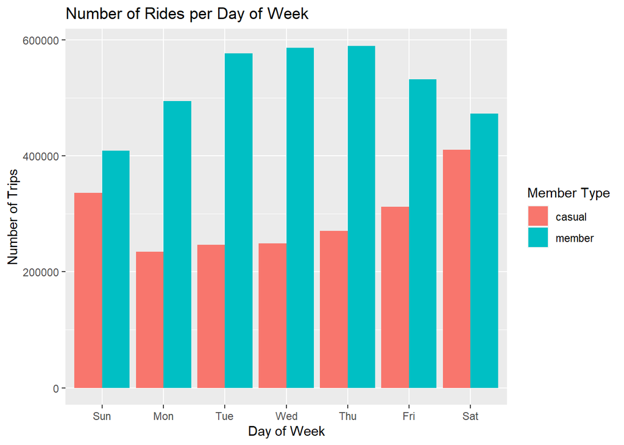

```r
## Plot number of rides by member type, options(scipen = ) is used to remove scientific value from results
options(scipen = 999)
ggplot(data = cleaned_trips) +
aes(x = day_of_week, fill = member_casual) +
geom_bar(position = 'dodge') +
labs(x = 'Day of Week', y = 'Number of Trips', fill = 'Member Type', title = 'Number of Rides per Day of Week')
```

Now I want to check trips by month.

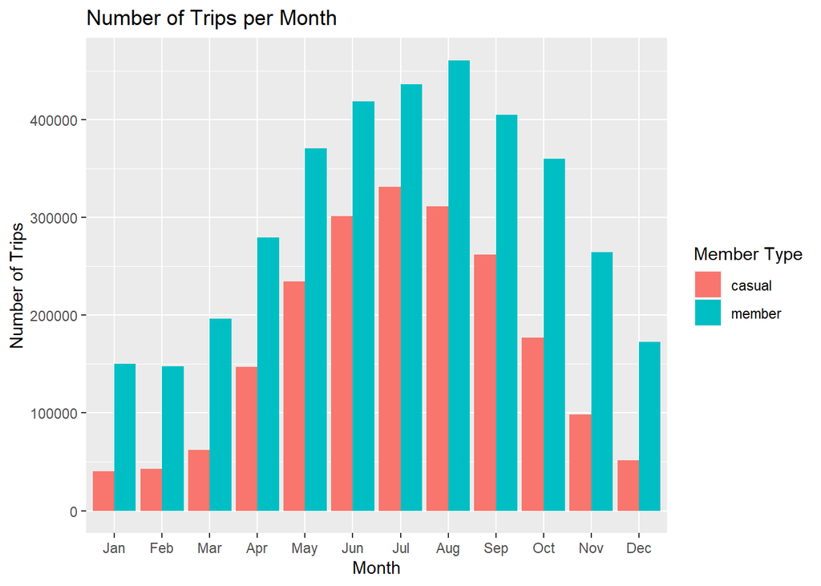

```r
## Plot number of trips by member type per month
ggplot(data = cleaned_trips) +
aes(x = month, fill = member_casual) +
geom_bar(position = 'dodge') +
labs(x = 'Month', y = 'Number of Trips', fill = 'Member Type', title = 'Number of Trips per Month')
```

Next, I want to explore trips on a micro level and look at the starting hours of each trip. This should further support my hypothesis about annual members using Cyclistic bikes for commuting purposes. This will be explained further in the analysis section of this project.

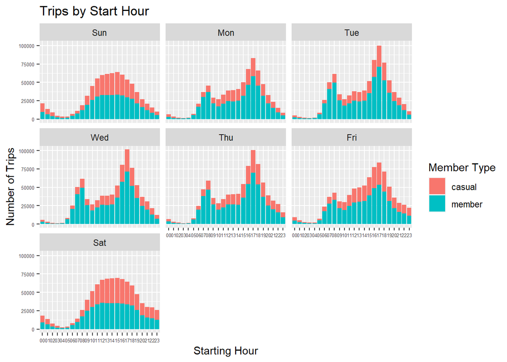

```r
## Plot trips per weekday by starting hour
ggplot(data = cleaned_trips) +
aes(x = start_hour, fill = member_casual) +
geom_bar() +
facet_wrap(~day_of_week) +
labs(x = 'Starting Hour', y = 'Number of Trips', fill = 'Member Type', title = 'Trips by Start Hour') +
theme(axis.text = element_text(size = 5))
```

I also calculated the average trip duration for every day. This data can be extremely helpful in understanding the purpose each member type derives from using the ride-share.

```r
## Find the average trip duration
average_trips <- aggregate(cleaned_trips$trip_duration, list(cleaned_trips$member_casual, cleaned_trips$day_of_week), FUN = mean)
```

Since aggregate() creates a table with placeholder column names, I want to rename the columns to make it easier to understand and analyze.

```r
## Rename the column names to make analysis easier
colnames(average_trips) <- c('member_type', 'day_of_week', 'average_duration')
```

```r
## Convert data types for use in ggplot, since <difftime> cannot be used
average_trips$day_of_week <- as.character(average_trips$day_of_week)

average_trips$average_duration <- as.numeric(average_trips$average_duration, units = 'secs')
```

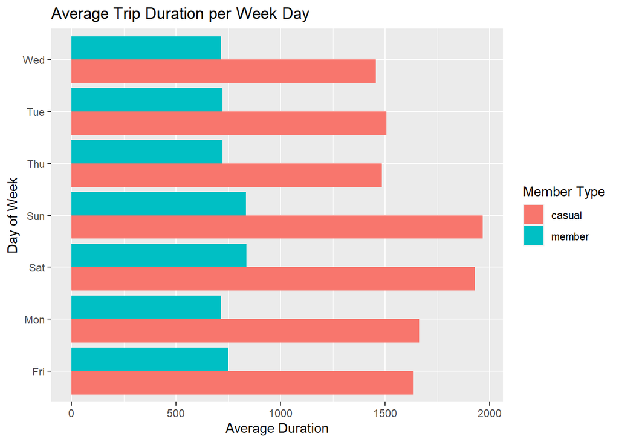

```r
## Create a plot showing the average trip duration throughout the week
ggplot(average_trips, aes(x = average_duration, y = day_of_week, fill = member_type)) +
geom_col(position = 'dodge') +
labs(x = 'Average Duration', y = 'Day of Week', fill = 'Member Type', title = 'Average Trip Duration per Week Day')
```

Now that I have more insight into how Cyclistic bikes are used, I want to explore where they are used. This information can help dictate which locations should be targeted for marketing based on the number of trips that occur.

```r
## Use descriptive analysis to find the most popular start and end stations for members and casual

## Most popular end stations for members
member_trips <- cleaned_trips[cleaned_trips$member_casual == 'member',]

 end_station_counts <- member_trips$end_station_name %>% table() %>%  sort(decreasing = TRUE)

head(end_station_counts, 10)
```

```
## .
##                              Clinton St & Washington Blvd
##                       547259                        27446
##     Kingsbury St & Kinzie St            Clark St & Elm St
##                        26367                        24859
##        Wells St & Concord Ln      Clinton St & Madison St
##                        22249                        22096
##            Wells St & Elm St     University Ave & 57th St
##                        20227                        20217
##         Broadway & Barry Ave       State St & Chicago Ave
##                        19393                        19029
```

```r
## Most popular start stations for members
member_trips <- cleaned_trips[cleaned_trips$member_casual == 'member',]

start_station_counts <- member_trips$start_station_name %>% table() %>% sort(decreasing = TRUE)

head(start_station_counts, 10)
```

```
## .
##                              Clinton St & Washington Blvd
##                       549587                        26216
##     Kingsbury St & Kinzie St            Clark St & Elm St
##                        26172                        25001
##        Wells St & Concord Ln      Clinton St & Madison St
##                        21419                        20596
##            Wells St & Elm St     University Ave & 57th St
##                        20400                        20038
##         Broadway & Barry Ave     Loomis St & Lexington St
##                        18959                        18901
```

```r
## Most popular end stations for casual users
casual_trips <- cleaned_trips[cleaned_trips$member_casual == 'casual',]

end_station_counts2 <- casual_trips$end_station_name %>% table() %>% sort(decreasing = TRUE)

head(end_station_counts2, 10)
```

```
## .
##                                               Streeter Dr & Grand Ave
##                             381943                              49310
##  DuSable Lake Shore Dr & Monroe St              Michigan Ave & Oak St
##                              27539                              23688
## DuSable Lake Shore Dr & North Blvd                    Millennium Park
##                              23256                              22220
##                Theater on the Lake                     Shedd Aquarium
##                              17574                              15658
##                     Dusable Harbor              Wells St & Concord Ln
##                              13558                              11924
```

```r
## Most popular start stations for casual users
casual_trips <- cleaned_trips[cleaned_trips$member_casual == 'casual',]

start_station_counts2 <- casual_trips$start_station_name %>% table() %>% sort(decreasing = TRUE)

head(start_station_counts2, 10)
```

```
## .
##                                               Streeter Dr & Grand Ave
##                             326129                              46030
##  DuSable Lake Shore Dr & Monroe St              Michigan Ave & Oak St
##                              30487                              22664
## DuSable Lake Shore Dr & North Blvd                    Millennium Park
##                              20338                              20228
##                     Shedd Aquarium                Theater on the Lake
##                              17783                              16359
##                     Dusable Harbor              Wells St & Concord Ln
##                              15491                              12171
```

## Analysis

From my exploration of the data, I have discovered a few distinguishing features in the usage between casual users and annual members.Let’s explore these differences together:

First, by graphing out ride-share usage throughout the week, we can see an immediate difference in how casual users and annual members ride. For annual members, the graph appears like a typical bell curve with a **higher volume of rides from Monday to Friday**, and the lowest volume of the week falling on Saturday and Sunday. This supports my hypothesis that **annual members are more likely to use ride-share for commuting purposes**.

For casual users, the opposite is true. I found higher ride volumes on weekend days (Friday, Saturday, Sunday), suggesting that **ride-share is more recreational for casual users**.

These findings are further supported when we zoom out and look at ride volume throughout the year. Ride volume for both members and casual users increases during the summer months with **peaks in August and July**, respectively. Since these are typically the warmest and sunniest months, this makes sense for both people using bikes for commuting and recreational purposes. The drastic **drop in volume for the months of December through February** is also expected, given the harshness of Chicago winters.

Looking at starting hours for rides throughout the week, there are **peaks of activity at 8:00am and 5:00pm on weekdays**. This activity is consistent for both casual users and annual members, meaning that *casual users may also use the ride-share app for commuting during the week*, however not at the same volume as annual members. For weekends, casual users and annual members also have similar behaviors. Trips typically started later in the afternoon, with less noticeable peaks, but a **more consistent usage in the afternoon hours**.

Based on the graph charting average ride duration by member type, casual users have significantly longer ride times compared to annual members. This makes sense given that casual users are using ride-shares for leisure versus annual members using them for transit.

## Recommendations

Revisiting the business task to determine differences between how casual users and annual members interact with Cyclistic, I can make a few recommendations for implementing a strategy to convert memberships.

First, since start hour behavior throughout the week is consistent between the member types, this suggests that casual members are also likely to use ride-shares to commute to and from work. These casual users can be targeted for advertising to encourage membership based on their frequent use of Cyclistic bicycles.

If large employers are located near popular stations, it may prove beneficial to partner with these businesses and offer discounted Cyclistic memberships for employees who commute. However this would require further research and effort to build relationships with those businesses.

## Closing Summary

The task was to identify how casual users and annual members use ride-share differently. I hypothesized that casual use was more recreational in nature, whereas members most likely take advantage of Cyclistic for commuting. I examined daily, weekly, and monthly usage of bicycles for each member type. This confirmed my hypothesis that annual members most likely used the ride-share to commute and casual users spiked on the weekends. However, casual users mirrored annual member start hours throughout the week, suggesting that casual users may also use ride-share to commute.

I suggest that advertisement be aimed at these casual users as they are the most likely to convert to annual memberships given their frequency of use. I also suggested that marketing be implemented near high traffic stations in order to maximize the reach of the campaign. This effort can be strengthened by further research into the areas surrounding popular stations and possibly partnering with businesses in the area to offer discounted Cyclistic membership to employees who commute to work.